# Risk Factor Analysis

## Outcome Variable

**Outcome Variable:** ever_co

## Predictor Variables

**Intervention Variable:** mbmi

**Adjustment Set:**

- arm
- W_mage
- meducyrs
- feducyrs
- hhwealth_quart
- W_nchldlt5
- brthmon
- W_parity
- delta_W_mage
- delta_meducyrs
- delta_feducyrs
- delta_hhwealth_quart
- delta_W_nchldlt5
- delta_brthmon
- delta_W_parity

## Stratifying Variables

The analysis was stratified on these variable(s):

- agecat
- studyid
- country

## Data Summary

| agecat | studyid | country | mbmi | ever_co | n_cell | n |
| --- | --- | --- | --- | --- | --- | --- |
| 0-24 months | iLiNS-Zinc | BURKINA FASO | Normal weight | 0 | 2453 | 3216 |
| 0-24 months | iLiNS-Zinc | BURKINA FASO | Normal weight | 1 | 309 | 3216 |
| 0-24 months | iLiNS-Zinc | BURKINA FASO | Underweight | 0 | 377 | 3216 |
| 0-24 months | iLiNS-Zinc | BURKINA FASO | Underweight | 1 | 77 | 3216 |
| 0-24 months | JiVitA-3 | BANGLADESH | Normal weight | 0 | 15066 | 26803 |
| 0-24 months | JiVitA-3 | BANGLADESH | Normal weight | 1 | 1470 | 26803 |
| 0-24 months | JiVitA-3 | BANGLADESH | Underweight | 0 | 9353 | 26803 |
| 0-24 months | JiVitA-3 | BANGLADESH | Underweight | 1 | 914 | 26803 |
| 0-24 months | LCNI-5 | MALAWI | Normal weight | 0 | 665 | 837 |
| 0-24 months | LCNI-5 | MALAWI | Normal weight | 1 | 27 | 837 |
| 0-24 months | LCNI-5 | MALAWI | Underweight | 0 | 130 | 837 |
| 0-24 months | LCNI-5 | MALAWI | Underweight | 1 | 15 | 837 |
| 0-24 months | MAL-ED | BANGLADESH | Normal weight | 0 | 194 | 254 |
| 0-24 months | MAL-ED | BANGLADESH | Normal weight | 1 | 28 | 254 |
| 0-24 months | MAL-ED | BANGLADESH | Underweight | 0 | 21 | 254 |
| 0-24 months | MAL-ED | BANGLADESH | Underweight | 1 | 11 | 254 |
| 0-24 months | MAL-ED | BRAZIL | Normal weight | 0 | 209 | 221 |
| 0-24 months | MAL-ED | BRAZIL | Normal weight | 1 | 2 | 221 |
| 0-24 months | MAL-ED | BRAZIL | Underweight | 0 | 10 | 221 |
| 0-24 months | MAL-ED | BRAZIL | Underweight | 1 | 0 | 221 |
| 0-24 months | MAL-ED | INDIA | Normal weight | 0 | 154 | 242 |
| 0-24 months | MAL-ED | INDIA | Normal weight | 1 | 39 | 242 |
| 0-24 months | MAL-ED | INDIA | Underweight | 0 | 35 | 242 |
| 0-24 months | MAL-ED | INDIA | Underweight | 1 | 14 | 242 |
| 0-24 months | MAL-ED | NEPAL | Normal weight | 0 | 216 | 238 |
| 0-24 months | MAL-ED | NEPAL | Normal weight | 1 | 22 | 238 |
| 0-24 months | MAL-ED | NEPAL | Underweight | 0 | 0 | 238 |
| 0-24 months | MAL-ED | NEPAL | Underweight | 1 | 0 | 238 |
| 0-24 months | MAL-ED | PERU | Normal weight | 0 | 275 | 290 |
| 0-24 months | MAL-ED | PERU | Normal weight | 1 | 10 | 290 |

[output cut: 170 more lines]

The following strata were considered:

- agecat: 0-24 months, studyid: iLiNS-Zinc, country: BURKINA FASO
- agecat: 0-24 months, studyid: JiVitA-3, country: BANGLADESH
- agecat: 0-24 months, studyid: LCNI-5, country: MALAWI
- agecat: 0-24 months, studyid: MAL-ED, country: BANGLADESH
- agecat: 0-24 months, studyid: MAL-ED, country: BRAZIL
- agecat: 0-24 months, studyid: MAL-ED, country: INDIA
- agecat: 0-24 months, studyid: MAL-ED, country: NEPAL
- agecat: 0-24 months, studyid: MAL-ED, country: PERU
- agecat: 0-24 months, studyid: MAL-ED, country: SOUTH AFRICA
- agecat: 0-24 months, studyid: MAL-ED, country: TANZANIA, UNITED REPUBLIC OF
- agecat: 0-24 months, studyid: NIH-Birth, country: BANGLADESH
- agecat: 0-24 months, studyid: NIH-Crypto, country: BANGLADESH
- agecat: 0-24 months, studyid: PROBIT, country: BELARUS
- agecat: 0-24 months, studyid: PROVIDE, country: BANGLADESH
- agecat: 0-24 months, studyid: SAS-CompFeed, country: INDIA
- agecat: 0-24 months, studyid: TanzaniaChild2, country: TANZANIA, UNITED REPUBLIC OF
- agecat: 0-24 months, studyid: ZVITAMBO, country: ZIMBABWE
- agecat: 0-6 months, studyid: JiVitA-3, country: BANGLADESH
- agecat: 0-6 months, studyid: LCNI-5, country: MALAWI
- agecat: 0-6 months, studyid: MAL-ED, country: BANGLADESH
- agecat: 0-6 months, studyid: MAL-ED, country: BRAZIL
- agecat: 0-6 months, studyid: MAL-ED, country: INDIA
- agecat: 0-6 months, studyid: MAL-ED, country: NEPAL
- agecat: 0-6 months, studyid: MAL-ED, country: PERU
- agecat: 0-6 months, studyid: MAL-ED, country: SOUTH AFRICA
- agecat: 0-6 months, studyid: MAL-ED, country: TANZANIA, UNITED REPUBLIC OF
- agecat: 0-6 months, studyid: NIH-Birth, country: BANGLADESH
- agecat: 0-6 months, studyid: NIH-Crypto, country: BANGLADESH
- agecat: 0-6 months, studyid: PROBIT, country: BELARUS
- agecat: 0-6 months, studyid: PROVIDE, country: BANGLADESH
- agecat: 0-6 months, studyid: SAS-CompFeed, country: INDIA
- agecat: 0-6 months, studyid: TanzaniaChild2, country: TANZANIA, UNITED REPUBLIC OF
- agecat: 0-6 months, studyid: ZVITAMBO, country: ZIMBABWE
- agecat: 6-24 months, studyid: iLiNS-Zinc, country: BURKINA FASO
- agecat: 6-24 months, studyid: JiVitA-3, country: BANGLADESH
- agecat: 6-24 months, studyid: LCNI-5, country: MALAWI
- agecat: 6-24 months, studyid: MAL-ED, country: BANGLADESH
- agecat: 6-24 months, studyid: MAL-ED, country: BRAZIL
- agecat: 6-24 months, studyid: MAL-ED, country: INDIA
- agecat: 6-24 months, studyid: MAL-ED, country: NEPAL
- agecat: 6-24 months, studyid: MAL-ED, country: PERU
- agecat: 6-24 months, studyid: MAL-ED, country: SOUTH AFRICA
- agecat: 6-24 months, studyid: MAL-ED, country: TANZANIA, UNITED REPUBLIC OF
- agecat: 6-24 months, studyid: NIH-Birth, country: BANGLADESH
- agecat: 6-24 months, studyid: NIH-Crypto, country: BANGLADESH
- agecat: 6-24 months, studyid: PROBIT, country: BELARUS
- agecat: 6-24 months, studyid: PROVIDE, country: BANGLADESH
- agecat: 6-24 months, studyid: SAS-CompFeed, country: INDIA
- agecat: 6-24 months, studyid: TanzaniaChild2, country: TANZANIA, UNITED REPUBLIC OF
- agecat: 6-24 months, studyid: ZVITAMBO, country: ZIMBABWE

### Dropped Strata

Some strata were dropped due to rare outcomes:

- agecat: 0-24 months, studyid: MAL-ED, country: BRAZIL
- agecat: 0-24 months, studyid: MAL-ED, country: NEPAL
- agecat: 0-24 months, studyid: MAL-ED, country: PERU
- agecat: 0-24 months, studyid: MAL-ED, country: SOUTH AFRICA
- agecat: 0-24 months, studyid: MAL-ED, country: TANZANIA, UNITED REPUBLIC OF
- agecat: 0-24 months, studyid: PROBIT, country: BELARUS
- agecat: 0-24 months, studyid: TanzaniaChild2, country: TANZANIA, UNITED REPUBLIC OF
- agecat: 0-6 months, studyid: LCNI-5, country: MALAWI
- agecat: 0-6 months, studyid: MAL-ED, country: BANGLADESH
- agecat: 0-6 months, studyid: MAL-ED, country: BRAZIL
- agecat: 0-6 months, studyid: MAL-ED, country: NEPAL
- agecat: 0-6 months, studyid: MAL-ED, country: PERU
- agecat: 0-6 months, studyid: MAL-ED, country: SOUTH AFRICA
- agecat: 0-6 months, studyid: MAL-ED, country: TANZANIA, UNITED REPUBLIC OF
- agecat: 0-6 months, studyid: NIH-Crypto, country: BANGLADESH
- agecat: 0-6 months, studyid: PROBIT, country: BELARUS
- agecat: 0-6 months, studyid: TanzaniaChild2, country: TANZANIA, UNITED REPUBLIC OF
- agecat: 6-24 months, studyid: MAL-ED, country: BRAZIL
- agecat: 6-24 months, studyid: MAL-ED, country: NEPAL
- agecat: 6-24 months, studyid: MAL-ED, country: PERU
- agecat: 6-24 months, studyid: MAL-ED, country: SOUTH AFRICA
- agecat: 6-24 months, studyid: MAL-ED, country: TANZANIA, UNITED REPUBLIC OF
- agecat: 6-24 months, studyid: PROBIT, country: BELARUS
- agecat: 6-24 months, studyid: TanzaniaChild2, country: TANZANIA, UNITED REPUBLIC OF

## Methods Detail

We’re interested in the causal parameters $E[Y_a]$ for all values of $a \in \mathcal{A}$. These parameters represent the mean outcome if, possibly contrary to fact, we intervened to set all units to have $A=a$. Under the randomization and positivity assumptions, these are identified by the statistical parameters $\psi_a=E_W[E_{Y|A,W}(Y|A=a,W)]$. In addition, we’re interested in the mean of $Y$, $E[Y]$ under no intervention (the observed mean). We will estimate these parameters by using SuperLearner to fit the relevant likelihood factors – $E_{Y|A,W}(Y|A=a,W)$ and $p(A=a|W)$, and then updating our likelihood fit using a joint TMLE.

For unadjusted analyses ($W=\{\}$), initial likelihoods were estimated using Lrnr_glm to estimate the simple $E(Y|A)$ and Lrnr_mean to estimate $p(A)$. For adjusted analyses, a small library containing Lrnr_glmnet, Lrnr_xgboost, and Lrnr_mean was used.

Having estimated these parameters, we will then use the delta method to estimate relative risks and attributable risks relative to a prespecified baseline level of $A$.

# Results Detail

## Results Plots

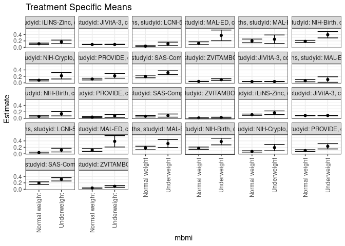

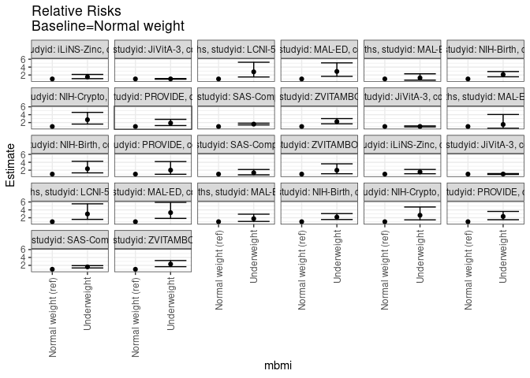

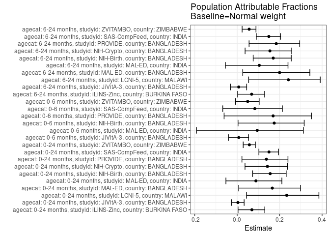

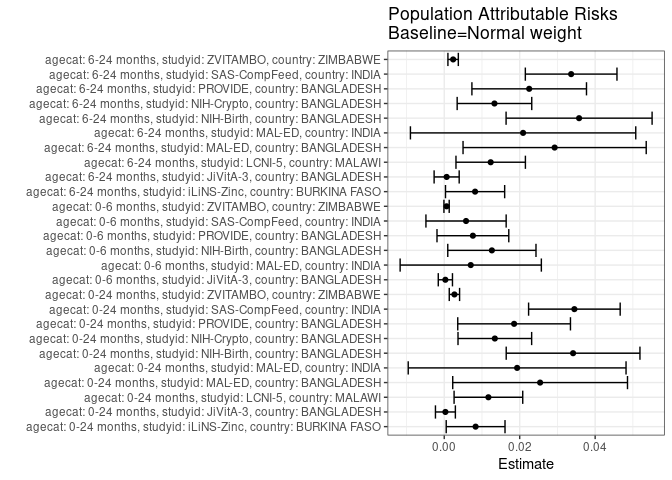

## Results Table

### Parameter: TSM

| agecat | studyid | country | intervention_level | baseline_level | estimate | ci_lower | ci_upper |
| --- | --- | --- | --- | --- | --- | --- | --- |
| 0-24 months | iLiNS-Zinc | BURKINA FASO | Normal weight | NA | 0.1117109 | 0.0921108 | 0.1313110 |
| 0-24 months | iLiNS-Zinc | BURKINA FASO | Underweight | NA | 0.1690655 | 0.1128650 | 0.2252660 |
| 0-24 months | JiVitA-3 | BANGLADESH | Normal weight | NA | 0.0886369 | 0.0838172 | 0.0934567 |
| 0-24 months | JiVitA-3 | BANGLADESH | Underweight | NA | 0.0894720 | 0.0837867 | 0.0951572 |
| 0-24 months | LCNI-5 | MALAWI | Normal weight | NA | 0.0384735 | 0.0241686 | 0.0527784 |
| 0-24 months | LCNI-5 | MALAWI | Underweight | NA | 0.1076455 | 0.0534349 | 0.1618560 |
| 0-24 months | MAL-ED | BANGLADESH | Normal weight | NA | 0.1281325 | 0.0841891 | 0.1720760 |
| 0-24 months | MAL-ED | BANGLADESH | Underweight | NA | 0.3707573 | 0.2047386 | 0.5367760 |
| 0-24 months | MAL-ED | INDIA | Normal weight | NA | 0.1996887 | 0.1426423 | 0.2567351 |
| 0-24 months | MAL-ED | INDIA | Underweight | NA | 0.2504915 | 0.1174942 | 0.3834888 |
| 0-24 months | NIH-Birth | BANGLADESH | Normal weight | NA | 0.1854023 | 0.1519128 | 0.2188918 |
| 0-24 months | NIH-Birth | BANGLADESH | Underweight | NA | 0.3907756 | 0.2932127 | 0.4883386 |
| 0-24 months | NIH-Crypto | BANGLADESH | Normal weight | NA | 0.0806333 | 0.0602381 | 0.1010286 |
| 0-24 months | NIH-Crypto | BANGLADESH | Underweight | NA | 0.2195826 | 0.1192279 | 0.3199372 |
| 0-24 months | PROVIDE | BANGLADESH | Normal weight | NA | 0.1160126 | 0.0892074 | 0.1428178 |
| 0-24 months | PROVIDE | BANGLADESH | Underweight | NA | 0.2172433 | 0.1437526 | 0.2907340 |
| 0-24 months | SAS-CompFeed | INDIA | Normal weight | NA | 0.1957197 | 0.1556530 | 0.2357864 |
| 0-24 months | SAS-CompFeed | INDIA | Underweight | NA | 0.3148068 | 0.2557379 | 0.3738757 |
| 0-24 months | ZVITAMBO | ZIMBABWE | Normal weight | NA | 0.0442644 | 0.0400765 | 0.0484523 |
| 0-24 months | ZVITAMBO | ZIMBABWE | Underweight | NA | 0.0995665 | 0.0720965 | 0.1270366 |
| 0-6 months | JiVitA-3 | BANGLADESH | Normal weight | NA | 0.0393335 | 0.0361890 | 0.0424779 |
| 0-6 months | JiVitA-3 | BANGLADESH | Underweight | NA | 0.0401090 | 0.0361760 | 0.0440420 |
| 0-6 months | MAL-ED | INDIA | Normal weight | NA | 0.0673575 | 0.0319236 | 0.1027914 |
| 0-6 months | MAL-ED | INDIA | Underweight | NA | 0.1020408 | 0.0171102 | 0.1869715 |
| 0-6 months | NIH-Birth | BANGLADESH | Normal weight | NA | 0.0597222 | 0.0393246 | 0.0801199 |
| 0-6 months | NIH-Birth | BANGLADESH | Underweight | NA | 0.1411589 | 0.0743159 | 0.2080018 |
| 0-6 months | PROVIDE | BANGLADESH | Normal weight | NA | 0.0372512 | 0.0213284 | 0.0531740 |
| 0-6 months | PROVIDE | BANGLADESH | Underweight | NA | 0.0746474 | 0.0298361 | 0.1194587 |
| 0-6 months | SAS-CompFeed | INDIA | Normal weight | NA | 0.0636861 | 0.0418558 | 0.0855164 |
| 0-6 months | SAS-CompFeed | INDIA | Underweight | NA | 0.0848104 | 0.0364308 | 0.1331900 |
| 0-6 months | ZVITAMBO | ZIMBABWE | Normal weight | NA | 0.0117880 | 0.0095873 | 0.0139886 |
| 0-6 months | ZVITAMBO | ZIMBABWE | Underweight | NA | 0.0233776 | 0.0100937 | 0.0366616 |
| 6-24 months | iLiNS-Zinc | BURKINA FASO | Normal weight | NA | 0.1118532 | 0.0921631 | 0.1315433 |
| 6-24 months | iLiNS-Zinc | BURKINA FASO | Underweight | NA | 0.1723625 | 0.1152722 | 0.2294527 |
| 6-24 months | JiVitA-3 | BANGLADESH | Normal weight | NA | 0.0862573 | 0.0803084 | 0.0922061 |
| 6-24 months | JiVitA-3 | BANGLADESH | Underweight | NA | 0.0880029 | 0.0812094 | 0.0947964 |
| 6-24 months | LCNI-5 | MALAWI | Normal weight | NA | 0.0387240 | 0.0243289 | 0.0531190 |
| 6-24 months | LCNI-5 | MALAWI | Underweight | NA | 0.1145648 | 0.0569277 | 0.1722018 |
| 6-24 months | MAL-ED | BANGLADESH | Normal weight | NA | 0.1171843 | 0.0735874 | 0.1607812 |
| 6-24 months | MAL-ED | BANGLADESH | Underweight | NA | 0.3859304 | 0.2104930 | 0.5613678 |
| 6-24 months | MAL-ED | INDIA | Normal weight | NA | 0.1799574 | 0.1247097 | 0.2352050 |
| 6-24 months | MAL-ED | INDIA | Underweight | NA | 0.3177753 | 0.1930569 | 0.4424938 |
| 6-24 months | NIH-Birth | BANGLADESH | Normal weight | NA | 0.1745896 | 0.1394459 | 0.2097332 |
| 6-24 months | NIH-Birth | BANGLADESH | Underweight | NA | 0.3796342 | 0.2767212 | 0.4825472 |
| 6-24 months | NIH-Crypto | BANGLADESH | Normal weight | NA | 0.0729932 | 0.0531022 | 0.0928843 |
| 6-24 months | NIH-Crypto | BANGLADESH | Underweight | NA | 0.1922376 | 0.0928283 | 0.2916468 |
| 6-24 months | PROVIDE | BANGLADESH | Normal weight | NA | 0.0998312 | 0.0738191 | 0.1258432 |
| 6-24 months | PROVIDE | BANGLADESH | Underweight | NA | 0.2321470 | 0.1507135 | 0.3135805 |
| 6-24 months | SAS-CompFeed | INDIA | Normal weight | NA | 0.1918900 | 0.1528512 | 0.2309288 |
| 6-24 months | SAS-CompFeed | INDIA | Underweight | NA | 0.3081543 | 0.2574336 | 0.3588750 |
| 6-24 months | ZVITAMBO | ZIMBABWE | Normal weight | NA | 0.0392997 | 0.0350735 | 0.0435259 |
| 6-24 months | ZVITAMBO | ZIMBABWE | Underweight | NA | 0.0909073 | 0.0624212 | 0.1193933 |

### Parameter: E(Y)

| agecat | studyid | country | intervention_level | baseline_level | estimate | ci_lower | ci_upper |
| --- | --- | --- | --- | --- | --- | --- | --- |
| 0-24 months | iLiNS-Zinc | BURKINA FASO | NA | NA | 0.1200249 | 0.0999720 | 0.1400777 |
| 0-24 months | JiVitA-3 | BANGLADESH | NA | NA | 0.0889453 | 0.0850200 | 0.0928705 |
| 0-24 months | LCNI-5 | MALAWI | NA | NA | 0.0501792 | 0.0353804 | 0.0649781 |
| 0-24 months | MAL-ED | BANGLADESH | NA | NA | 0.1535433 | 0.1091205 | 0.1979661 |
| 0-24 months | MAL-ED | INDIA | NA | NA | 0.2190083 | 0.1667935 | 0.2712230 |
| 0-24 months | NIH-Birth | BANGLADESH | NA | NA | 0.2195513 | 0.1870467 | 0.2520558 |
| 0-24 months | NIH-Crypto | BANGLADESH | NA | NA | 0.0940397 | 0.0732057 | 0.1148737 |
| 0-24 months | PROVIDE | BANGLADESH | NA | NA | 0.1345291 | 0.1086533 | 0.1604050 |
| 0-24 months | SAS-CompFeed | INDIA | NA | NA | 0.2302158 | 0.1856981 | 0.2747335 |
| 0-24 months | ZVITAMBO | ZIMBABWE | NA | NA | 0.0469627 | 0.0427729 | 0.0511526 |
| 0-6 months | JiVitA-3 | BANGLADESH | NA | NA | 0.0396314 | 0.0371179 | 0.0421449 |
| 0-6 months | MAL-ED | INDIA | NA | NA | 0.0743802 | 0.0412530 | 0.1075073 |
| 0-6 months | NIH-Birth | BANGLADESH | NA | NA | 0.0723473 | 0.0519719 | 0.0927227 |
| 0-6 months | PROVIDE | BANGLADESH | NA | NA | 0.0448430 | 0.0291486 | 0.0605375 |
| 0-6 months | SAS-CompFeed | INDIA | NA | NA | 0.0694645 | 0.0441638 | 0.0947653 |
| 0-6 months | ZVITAMBO | ZIMBABWE | NA | NA | 0.0124026 | 0.0102064 | 0.0145989 |
| 6-24 months | iLiNS-Zinc | BURKINA FASO | NA | NA | 0.1200249 | 0.0999720 | 0.1400777 |
| 6-24 months | JiVitA-3 | BANGLADESH | NA | NA | 0.0868934 | 0.0822223 | 0.0915646 |
| 6-24 months | LCNI-5 | MALAWI | NA | NA | 0.0510328 | 0.0359888 | 0.0660768 |
| 6-24 months | MAL-ED | BANGLADESH | NA | NA | 0.1464435 | 0.1015265 | 0.1913605 |
| 6-24 months | MAL-ED | INDIA | NA | NA | 0.2008547 | 0.1494120 | 0.2522974 |
| 6-24 months | NIH-Birth | BANGLADESH | NA | NA | 0.2103321 | 0.1759902 | 0.2446740 |
| 6-24 months | NIH-Crypto | BANGLADESH | NA | NA | 0.0863014 | 0.0659171 | 0.1066856 |
| 6-24 months | PROVIDE | BANGLADESH | NA | NA | 0.1223491 | 0.0963874 | 0.1483108 |
| 6-24 months | SAS-CompFeed | INDIA | NA | NA | 0.2255286 | 0.1871466 | 0.2639106 |
| 6-24 months | ZVITAMBO | ZIMBABWE | NA | NA | 0.0416521 | 0.0374281 | 0.0458762 |

### Parameter: RR

| agecat | studyid | country | intervention_level | baseline_level | estimate | ci_lower | ci_upper |
| --- | --- | --- | --- | --- | --- | --- | --- |
| 0-24 months | iLiNS-Zinc | BURKINA FASO | Normal weight | Normal weight | 1.000000 | 1.0000000 | 1.000000 |
| 0-24 months | iLiNS-Zinc | BURKINA FASO | Underweight | Normal weight | 1.513421 | 1.0716384 | 2.137327 |
| 0-24 months | JiVitA-3 | BANGLADESH | Normal weight | Normal weight | 1.000000 | 1.0000000 | 1.000000 |
| 0-24 months | JiVitA-3 | BANGLADESH | Underweight | Normal weight | 1.009421 | 0.9339532 | 1.090987 |
| 0-24 months | LCNI-5 | MALAWI | Normal weight | Normal weight | 1.000000 | 1.0000000 | 1.000000 |
| 0-24 months | LCNI-5 | MALAWI | Underweight | Normal weight | 2.797912 | 1.4954337 | 5.234809 |
| 0-24 months | MAL-ED | BANGLADESH | Normal weight | Normal weight | 1.000000 | 1.0000000 | 1.000000 |
| 0-24 months | MAL-ED | BANGLADESH | Underweight | Normal weight | 2.893545 | 1.6497227 | 5.075158 |
| 0-24 months | MAL-ED | INDIA | Normal weight | Normal weight | 1.000000 | 1.0000000 | 1.000000 |
| 0-24 months | MAL-ED | INDIA | Underweight | Normal weight | 1.254410 | 0.6854175 | 2.295747 |
| 0-24 months | NIH-Birth | BANGLADESH | Normal weight | Normal weight | 1.000000 | 1.0000000 | 1.000000 |
| 0-24 months | NIH-Birth | BANGLADESH | Underweight | Normal weight | 2.107717 | 1.5475989 | 2.870557 |
| 0-24 months | NIH-Crypto | BANGLADESH | Normal weight | Normal weight | 1.000000 | 1.0000000 | 1.000000 |
| 0-24 months | NIH-Crypto | BANGLADESH | Underweight | Normal weight | 2.723224 | 1.6161977 | 4.588515 |
| 0-24 months | PROVIDE | BANGLADESH | Normal weight | Normal weight | 1.000000 | 1.0000000 | 1.000000 |
| 0-24 months | PROVIDE | BANGLADESH | Underweight | Normal weight | 1.872584 | 1.2434734 | 2.819979 |
| 0-24 months | SAS-CompFeed | INDIA | Normal weight | Normal weight | 1.000000 | 1.0000000 | 1.000000 |
| 0-24 months | SAS-CompFeed | INDIA | Underweight | Normal weight | 1.608457 | 1.4054582 | 1.840776 |
| 0-24 months | ZVITAMBO | ZIMBABWE | Normal weight | Normal weight | 1.000000 | 1.0000000 | 1.000000 |
| 0-24 months | ZVITAMBO | ZIMBABWE | Underweight | Normal weight | 2.249359 | 1.6804487 | 3.010871 |
| 0-6 months | JiVitA-3 | BANGLADESH | Normal weight | Normal weight | 1.000000 | 1.0000000 | 1.000000 |
| 0-6 months | JiVitA-3 | BANGLADESH | Underweight | Normal weight | 1.019717 | 0.9013062 | 1.153684 |
| 0-6 months | MAL-ED | INDIA | Normal weight | Normal weight | 1.000000 | 1.0000000 | 1.000000 |
| 0-6 months | MAL-ED | INDIA | Underweight | Normal weight | 1.514914 | 0.5659383 | 4.055148 |
| 0-6 months | NIH-Birth | BANGLADESH | Normal weight | Normal weight | 1.000000 | 1.0000000 | 1.000000 |
| 0-6 months | NIH-Birth | BANGLADESH | Underweight | Normal weight | 2.363590 | 1.3173830 | 4.240648 |
| 0-6 months | PROVIDE | BANGLADESH | Normal weight | Normal weight | 1.000000 | 1.0000000 | 1.000000 |
| 0-6 months | PROVIDE | BANGLADESH | Underweight | Normal weight | 2.003891 | 0.9600573 | 4.182645 |
| 0-6 months | SAS-CompFeed | INDIA | Normal weight | Normal weight | 1.000000 | 1.0000000 | 1.000000 |
| 0-6 months | SAS-CompFeed | INDIA | Underweight | Normal weight | 1.331693 | 0.8176205 | 2.168985 |
| 0-6 months | ZVITAMBO | ZIMBABWE | Normal weight | Normal weight | 1.000000 | 1.0000000 | 1.000000 |
| 0-6 months | ZVITAMBO | ZIMBABWE | Underweight | Normal weight | 1.983181 | 1.0904327 | 3.606832 |
| 6-24 months | iLiNS-Zinc | BURKINA FASO | Normal weight | Normal weight | 1.000000 | 1.0000000 | 1.000000 |
| 6-24 months | iLiNS-Zinc | BURKINA FASO | Underweight | Normal weight | 1.540970 | 1.0897758 | 2.178971 |
| 6-24 months | JiVitA-3 | BANGLADESH | Normal weight | Normal weight | 1.000000 | 1.0000000 | 1.000000 |
| 6-24 months | JiVitA-3 | BANGLADESH | Underweight | Normal weight | 1.020238 | 0.9240151 | 1.126481 |
| 6-24 months | LCNI-5 | MALAWI | Normal weight | Normal weight | 1.000000 | 1.0000000 | 1.000000 |
| 6-24 months | LCNI-5 | MALAWI | Underweight | Normal weight | 2.958496 | 1.5829448 | 5.529377 |
| 6-24 months | MAL-ED | BANGLADESH | Normal weight | Normal weight | 1.000000 | 1.0000000 | 1.000000 |
| 6-24 months | MAL-ED | BANGLADESH | Underweight | Normal weight | 3.293363 | 1.8361313 | 5.907114 |
| 6-24 months | MAL-ED | INDIA | Normal weight | Normal weight | 1.000000 | 1.0000000 | 1.000000 |
| 6-24 months | MAL-ED | INDIA | Underweight | Normal weight | 1.765837 | 1.0740830 | 2.903109 |
| 6-24 months | NIH-Birth | BANGLADESH | Normal weight | Normal weight | 1.000000 | 1.0000000 | 1.000000 |
| 6-24 months | NIH-Birth | BANGLADESH | Underweight | Normal weight | 2.174438 | 1.5503209 | 3.049808 |
| 6-24 months | NIH-Crypto | BANGLADESH | Normal weight | Normal weight | 1.000000 | 1.0000000 | 1.000000 |
| 6-24 months | NIH-Crypto | BANGLADESH | Underweight | Normal weight | 2.633635 | 1.4688097 | 4.722215 |
| 6-24 months | PROVIDE | BANGLADESH | Normal weight | Normal weight | 1.000000 | 1.0000000 | 1.000000 |
| 6-24 months | PROVIDE | BANGLADESH | Underweight | Normal weight | 2.325396 | 1.5038693 | 3.595703 |
| 6-24 months | SAS-CompFeed | INDIA | Normal weight | Normal weight | 1.000000 | 1.0000000 | 1.000000 |
| 6-24 months | SAS-CompFeed | INDIA | Underweight | Normal weight | 1.605890 | 1.3394394 | 1.925345 |
| 6-24 months | ZVITAMBO | ZIMBABWE | Normal weight | Normal weight | 1.000000 | 1.0000000 | 1.000000 |
| 6-24 months | ZVITAMBO | ZIMBABWE | Underweight | Normal weight | 2.313181 | 1.6610243 | 3.221389 |

### Parameter: PAR

| agecat | studyid | country | intervention_level | baseline_level | estimate | ci_lower | ci_upper |
| --- | --- | --- | --- | --- | --- | --- | --- |
| 0-24 months | iLiNS-Zinc | BURKINA FASO | Normal weight | NA | 0.0083140 | 0.0005210 | 0.0161070 |
| 0-24 months | JiVitA-3 | BANGLADESH | Normal weight | NA | 0.0003083 | -0.0023318 | 0.0029484 |
| 0-24 months | LCNI-5 | MALAWI | Normal weight | NA | 0.0117057 | 0.0026077 | 0.0208038 |
| 0-24 months | MAL-ED | BANGLADESH | Normal weight | NA | 0.0254108 | 0.0022477 | 0.0485738 |
| 0-24 months | MAL-ED | INDIA | Normal weight | NA | 0.0193196 | -0.0095495 | 0.0481887 |
| 0-24 months | NIH-Birth | BANGLADESH | Normal weight | NA | 0.0341490 | 0.0164240 | 0.0518739 |
| 0-24 months | NIH-Crypto | BANGLADESH | Normal weight | NA | 0.0134064 | 0.0036470 | 0.0231659 |
| 0-24 months | PROVIDE | BANGLADESH | Normal weight | NA | 0.0185166 | 0.0035783 | 0.0334548 |
| 0-24 months | SAS-CompFeed | INDIA | Normal weight | NA | 0.0344961 | 0.0223587 | 0.0466334 |
| 0-24 months | ZVITAMBO | ZIMBABWE | Normal weight | NA | 0.0026983 | 0.0013305 | 0.0040661 |
| 0-6 months | JiVitA-3 | BANGLADESH | Normal weight | NA | 0.0002979 | -0.0015838 | 0.0021797 |
| 0-6 months | MAL-ED | INDIA | Normal weight | NA | 0.0070227 | -0.0116936 | 0.0257389 |
| 0-6 months | NIH-Birth | BANGLADESH | Normal weight | NA | 0.0126250 | 0.0009320 | 0.0243180 |
| 0-6 months | PROVIDE | BANGLADESH | Normal weight | NA | 0.0075918 | -0.0019225 | 0.0171062 |
| 0-6 months | SAS-CompFeed | INDIA | Normal weight | NA | 0.0057784 | -0.0048546 | 0.0164114 |
| 0-6 months | ZVITAMBO | ZIMBABWE | Normal weight | NA | 0.0006147 | -0.0000848 | 0.0013142 |
| 6-24 months | iLiNS-Zinc | BURKINA FASO | Normal weight | NA | 0.0081717 | 0.0003314 | 0.0160120 |
| 6-24 months | JiVitA-3 | BANGLADESH | Normal weight | NA | 0.0006362 | -0.0026862 | 0.0039586 |
| 6-24 months | LCNI-5 | MALAWI | Normal weight | NA | 0.0123088 | 0.0031064 | 0.0215113 |
| 6-24 months | MAL-ED | BANGLADESH | Normal weight | NA | 0.0292592 | 0.0049821 | 0.0535363 |
| 6-24 months | MAL-ED | INDIA | Normal weight | NA | 0.0208973 | -0.0089665 | 0.0507612 |
| 6-24 months | NIH-Birth | BANGLADESH | Normal weight | NA | 0.0357426 | 0.0163911 | 0.0550940 |
| 6-24 months | NIH-Crypto | BANGLADESH | Normal weight | NA | 0.0133081 | 0.0034233 | 0.0231930 |
| 6-24 months | PROVIDE | BANGLADESH | Normal weight | NA | 0.0225179 | 0.0073311 | 0.0377048 |
| 6-24 months | SAS-CompFeed | INDIA | Normal weight | NA | 0.0336386 | 0.0214938 | 0.0457833 |
| 6-24 months | ZVITAMBO | ZIMBABWE | Normal weight | NA | 0.0023524 | 0.0009729 | 0.0037320 |

### Parameter: PAF

| agecat | studyid | country | intervention_level | baseline_level | estimate | ci_lower | ci_upper |
| --- | --- | --- | --- | --- | --- | --- | --- |
| 0-24 months | iLiNS-Zinc | BURKINA FASO | Normal weight | NA | 0.0692691 | 0.0040686 | 0.1302012 |
| 0-24 months | JiVitA-3 | BANGLADESH | Normal weight | NA | 0.0034665 | -0.0266693 | 0.0327177 |
| 0-24 months | LCNI-5 | MALAWI | Normal weight | NA | 0.2332781 | 0.0440375 | 0.3850569 |
| 0-24 months | MAL-ED | BANGLADESH | Normal weight | NA | 0.1654957 | 0.0072933 | 0.2984863 |
| 0-24 months | MAL-ED | INDIA | Normal weight | NA | 0.0882139 | -0.0530835 | 0.2105527 |
| 0-24 months | NIH-Birth | BANGLADESH | Normal weight | NA | 0.1555398 | 0.0727058 | 0.2309744 |
| 0-24 months | NIH-Crypto | BANGLADESH | Normal weight | NA | 0.1425612 | 0.0368297 | 0.2366861 |
| 0-24 months | PROVIDE | BANGLADESH | Normal weight | NA | 0.1376397 | 0.0223643 | 0.2393227 |
| 0-24 months | SAS-CompFeed | INDIA | Normal weight | NA | 0.1498424 | 0.1023206 | 0.1948484 |
| 0-24 months | ZVITAMBO | ZIMBABWE | Normal weight | NA | 0.0574567 | 0.0282850 | 0.0857526 |
| 0-6 months | JiVitA-3 | BANGLADESH | Normal weight | NA | 0.0075177 | -0.0411225 | 0.0538854 |
| 0-6 months | MAL-ED | INDIA | Normal weight | NA | 0.0944157 | -0.1916684 | 0.3118195 |
| 0-6 months | NIH-Birth | BANGLADESH | Normal weight | NA | 0.1745060 | 0.0040603 | 0.3157815 |
| 0-6 months | PROVIDE | BANGLADESH | Normal weight | NA | 0.1692977 | -0.0616132 | 0.3499833 |
| 0-6 months | SAS-CompFeed | INDIA | Normal weight | NA | 0.0831849 | -0.0679859 | 0.2129578 |
| 0-6 months | ZVITAMBO | ZIMBABWE | Normal weight | NA | 0.0495599 | -0.0078429 | 0.1036933 |
| 6-24 months | iLiNS-Zinc | BURKINA FASO | Normal weight | NA | 0.0680832 | 0.0023234 | 0.1295085 |
| 6-24 months | JiVitA-3 | BANGLADESH | Normal weight | NA | 0.0073214 | -0.0316951 | 0.0448623 |
| 6-24 months | LCNI-5 | MALAWI | Normal weight | NA | 0.2411943 | 0.0541263 | 0.3912654 |
| 6-24 months | MAL-ED | BANGLADESH | Normal weight | NA | 0.1997986 | 0.0263024 | 0.3423807 |
| 6-24 months | MAL-ED | INDIA | Normal weight | NA | 0.1040421 | -0.0555236 | 0.2394859 |
| 6-24 months | NIH-Birth | BANGLADESH | Normal weight | NA | 0.1699339 | 0.0754313 | 0.2547771 |
| 6-24 months | NIH-Crypto | BANGLADESH | Normal weight | NA | 0.1542053 | 0.0371908 | 0.2569986 |
| 6-24 months | PROVIDE | BANGLADESH | Normal weight | NA | 0.1840466 | 0.0560860 | 0.2946605 |
| 6-24 months | SAS-CompFeed | INDIA | Normal weight | NA | 0.1491543 | 0.0900913 | 0.2043834 |
| 6-24 months | ZVITAMBO | ZIMBABWE | Normal weight | NA | 0.0564784 | 0.0232197 | 0.0886048 |